# Roulette

Ty Painter

September 06, 2020

# 1 Introduction

I will be running simulations to answer multiple questions regarding the efficiency of the “Martingale” strategy when playing Roulette. I will calculate the average earnings that a gambler can expect, along with the probability of walking out with a profit when using this strategy. I will also examine how a gambler’s earnings will evolve over a series of plays.

Other factors I will study are the affects of the average earnings by changing an input parameter and how the stopping rules impact the number of plays a gambler completes.

## 1.1 Background

Roulette is a popular game found at casinos and many other places. It is a round table of 38 evenly-sized pockets on a wheel, composed of 18 black, 18 red, and 2 green pockets. Each pocket is also numbered. To win in Roulette, a gambler must pick a pocket (by color, number, odd/even, etc.) where the marble comes to rest. For this simulation we are picking by color (red) in which the payout is $1 for each $1 wagered. An example would be a gambler bets $5 on red and if the marble lands on red, then the gambler would receive the $5 bet back, along with an addition $5 in winnings for a total of $10. If the marble landed on black, then the gambler would lose the $5 bet.

I will be using the “Martingale” strategy to play Roulette in this simulation. The flowchart below provides the process to follow the Martingale strategy.

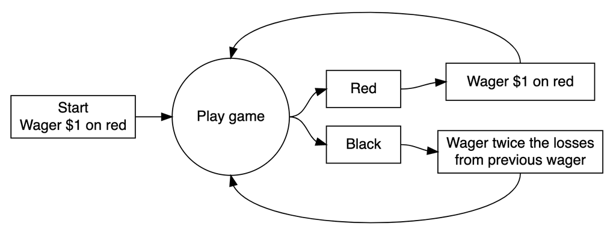

# 2 Methods

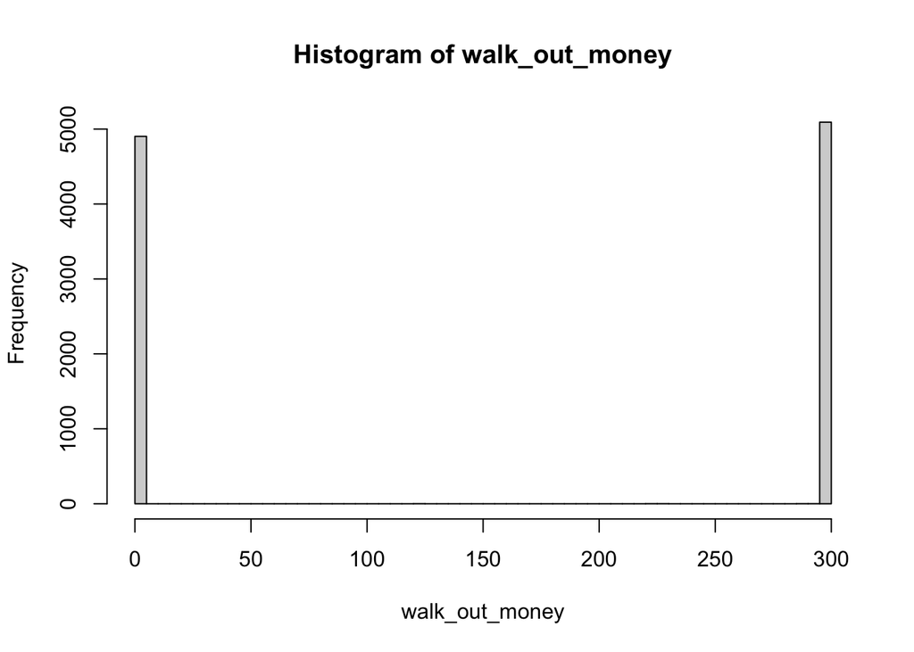

```r
#' A single play of the Martingale strategy
#'
#' Takes a state list, spins the roulette wheel, returns the state list with updated values (for example, budget, plays, etc)
#' @param state A list with the following entries:
#'   B              number, the budget
#'   W              number, the budget threshold for successfully stoping
#'   L              number, the maximum number of plays
#'   M              number, the casino wager limit
#'   plays          integer, the number of plays executed
#'   previous_wager number, the wager in the previous play (0 at first play)
#'   previous_win   TRUE/FALSE, indicator if the previous play was a win (TRUE at first play)
#' @return The updated state list
one_play <- function(state){

    # Wager
    proposed_wager <- ifelse(state$previous_win, 1, 2*state$previous_wager)
    wager <- min(proposed_wager, state$M, state$B)

    # Spin of the wheel
    # Returns 1 for TRUE, 0 for FALSE
    red <- rbinom(1,1,18/38)

    # Update state
    state$plays <- state$plays + 1
    state$previous_wager <- wager
    if(red){
      # WIN is if red = 1 (true)
      state$B <- state$B + wager
      state$previous_win <- TRUE
    }else{
      # LOSE is if red = 0 (false)
      state$B <- state$B - wager
      state$previous_win <- FALSE
    }
  state
}


#' Stopping rule
#'
#' Takes the state list and determines if the gambler has to stop
#' @param state A list.  See one_play
#' @return TRUE/FALSE
stop_play <- function(state){
  if(state$B <= 0) return(TRUE)
  if(state$plays >= state$L) return(TRUE)
  if(state$B >= state$W) return(TRUE)
  FALSE
}


#' Play roulette to either bankruptcy, success, or play limits
#'
#' @param B number, the starting budget
#' @param W number, the budget threshold for successfully stopping
#' @param L number, the maximum number of plays
#' @param M number, the casino wager limit
#' @return A vector of budget values calculated after each play.
one_series <- function(
    B = 200
  , W = 300
  , L = 1000
  , M = 100
){

  # initial state
  state <- list(
    B = B
  , W = W
  , L = L
  , M = M
  , plays = 0
  , previous_wager = 0
  , previous_win = TRUE
  )

  # vector to store budget over series of plays
  budget <- rep(NA, L)

  # For loop of plays
  for(i in 1:L){
    new_state <- state %>% one_play
    budget[i] <- new_state$B
    if(new_state %>% stop_play){
      return(budget[1:i])
    }
    state <- new_state
  }
  budget
}

# helper function
get_last <- function(x) x[length(x)]


# Simulation
walk_out_money <- rep(NA, 10000)
for(j in seq_along(walk_out_money)){
  walk_out_money[j] <- one_series(B = 200, W = 300, L = 1000, M = 100) %>% get_last
}

# Walk out money distribution
hist(walk_out_money, breaks = 100)
```

```r
# Estimated probability of walking out with extra cash
mean(walk_out_money > 200)
```

```
## [1] 0.5096
```

```r
# Estimated earnings
mean(walk_out_money - 200)
```

```
## [1] -47.1245
```

In the histogram above, you can see the distribution of the two possible outcomes of either walking out bankrupt with $0 or walking out with the maximum winnings threshold of $300. In this case, there are slightly more instances where the gambler is walking out with the maximum profit (5,096) compared to walking out bankrupt (4,904) producing a winning probability of 50.96%. To calculate the average earnings, I found the amount of money the gambler walked away with after each simulation and subtracted the starting budget of $200 to find the profit/loss margin. I used each of 10,000 profits/losses from each simulation to find the total average loss of -$47.12.

The probability of walking out with a profit and the estimated earnings calculations can be a bit deceiving. While the probability of walking out with the maximum profit is over 50%, the average earning is actually negative implying the the gambler will walk away on average losing money. I believe this is due to difference in the maximum winnings threshold (+$100) and maximum loss threshold (-$200). The average earnings are skewed because of the profit/loss limits. Every time the gambler goes bankrupt, the loss is $200, but every time the gambler hits the maximum winnings, the profit is only $100. So even though in this simulation the gambler won more times than not, the losses are worth more when calculating the average. Also, by setting the profit limit lower you can decrease the number of plays the gambler can attempt, thus increasing the chances of profiting. This is because the odds are in the houses favor and with each additional play the gambler incrementally decreases their chances of winning. If you were to increase the maximum winnings threshold by another $100 to a total of $400 to make the profit/loss limits equal, you would see a dramatic decrease in the probability of winning. In the histogram below, the probability of walking out a winner decreased from 50.96% to 30.49%.

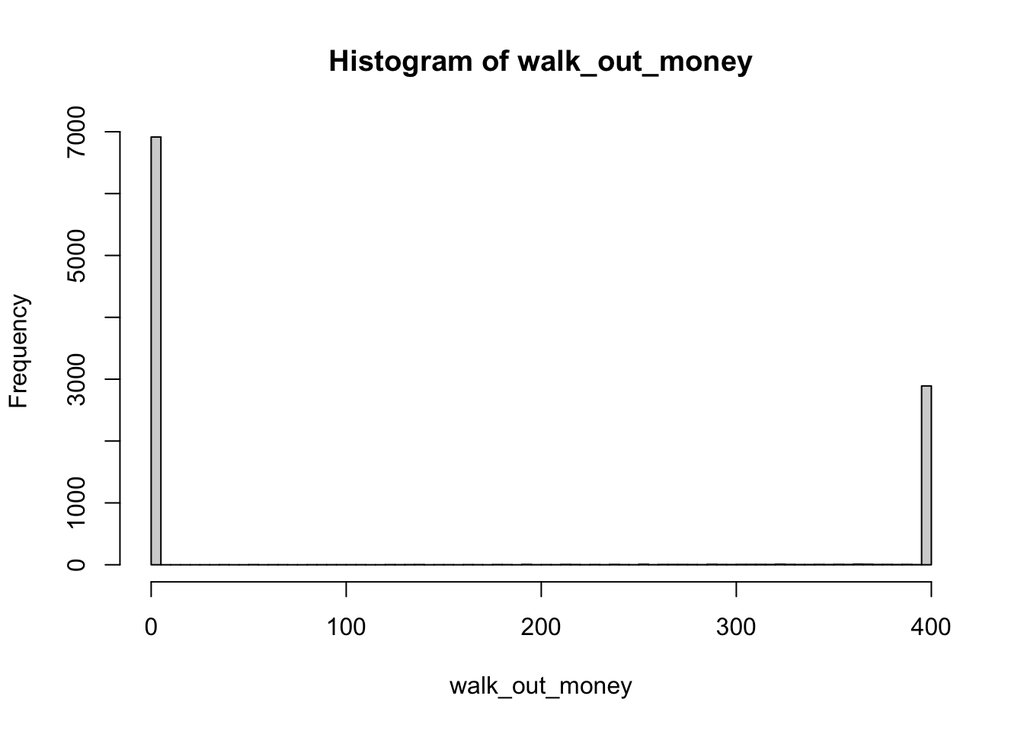

```r
# Simulation with winning threshold increased to $400
walk_out_money <- rep(NA, 10000)
for(j in seq_along(walk_out_money)){
  walk_out_money[j] <- one_series(B = 200, W = 400, L = 1000, M = 100) %>% get_last
}

# Walk out money distribution
hist(walk_out_money, breaks = 100)
```

```r
# Estimated probability of walking out with extra cash
mean(walk_out_money > 200)
```

```
## [1] 0.3049
```

```r
# Estimated earnings
mean(walk_out_money - 200)
```

```
## [1] -78.965
```

Another way to decrease your number of plays is to increase your betting wager. If you decide to increase your betting wager from $1 to $50 then your chances of winning along with expected earnings increase.

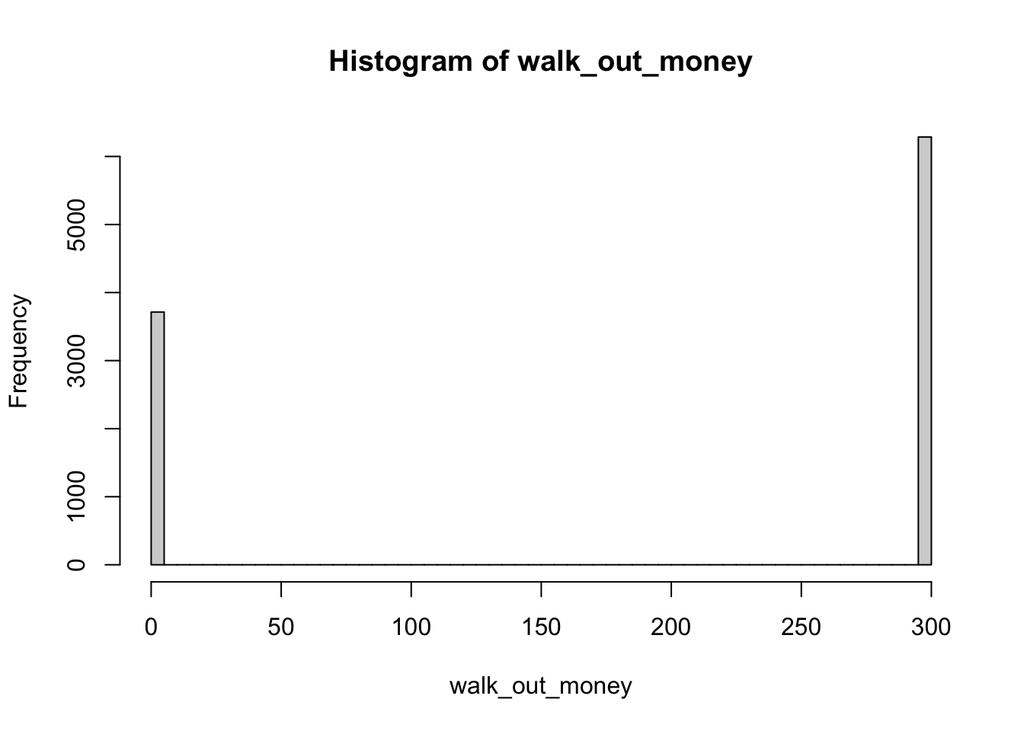

```r
# A single play of the Martingale strategy increasing the betting wager to $50
one_play <- function(state){

    # Wager
    proposed_wager <- ifelse(state$previous_win, 50, 2*state$previous_wager)
    wager <- min(proposed_wager, state$M, state$B)

    # Spin of the wheel
    # Returns 1 for TRUE, 0 for FALSE
    red <- rbinom(1,1,18/38)

    # Update state
    state$plays <- state$plays + 1
    state$previous_wager <- wager
    if(red){
      # WIN is if red = 1 (true)
      state$B <- state$B + wager
      state$previous_win <- TRUE
    }else{
      # LOSE is if red = 0 (false)
      state$B <- state$B - wager
      state$previous_win <- FALSE
    }
  state
}

# Simulation
walk_out_money <- rep(NA, 10000)
for(j in seq_along(walk_out_money)){
  walk_out_money[j] <- one_series(B = 200, W = 300, L = 1000, M = 100) %>% get_last
}

# Walk out money distribution
hist(walk_out_money, breaks = 100)
```

```r
# Estimated probability of walking out with extra cash
mean(walk_out_money > 200)
```

```
## [1] 0.6286
```

```r
# Estimated earnings
mean(walk_out_money - 200)
```

```
## [1] -11.42
```

Since the number of plays and probability of winning/estimated earnings are inversely related, decreasing the number of plays threshold for stopping from 1,000 plays to 100 plays significantly increases the probability of winning (68.67%) and decreases the estimated loss ($21.08) in the histogram and calculations below.

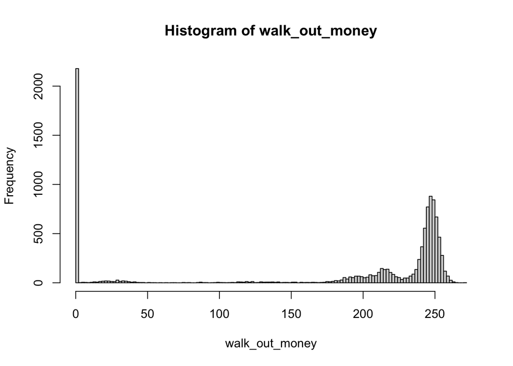

```r
# A single play of the Martingale strategy
one_play <- function(state){

    # Wager
    proposed_wager <- ifelse(state$previous_win, 1, 2*state$previous_wager)
    wager <- min(proposed_wager, state$M, state$B)

    # Spin of the wheel
    # Returns 1 for TRUE, 0 for FALSE
    red <- rbinom(1,1,18/38)

    # Update state
    state$plays <- state$plays + 1
    state$previous_wager <- wager
    if(red){
      # WIN is if red = 1 (true)
      state$B <- state$B + wager
      state$previous_win <- TRUE
    }else{
      # LOSE is if red = 0 (false)
      state$B <- state$B - wager
      state$previous_win <- FALSE
    }
  state
}
# Simulation for decreasing the plays limit to 100
walk_out_money <- rep(NA, 10000)
for(j in seq_along(walk_out_money)){
  walk_out_money[j] <- one_series(B = 200, W = 300, L = 100, M = 100) %>% get_last
}

# Walk out money distribution
hist(walk_out_money, breaks = 100)
```

```r
# Estimated probability of walking out with extra cash
mean(walk_out_money > 200)
```

```
## [1] 0.6867
```

```r
# Estimated earnings
mean(walk_out_money - 200)
```

```
## [1] -21.08
```

# 3 Results

```r
#' Count number of plays to either bankruptcy, success, or play limits
#'
#' @param B number, the starting budget
#' @param W number, the budget threshold for successfully stoping
#' @param L number, the maximum number of plays
#' @param M number, the casino wager limit
#' @return A vector of budget values calculated after each play.
one_series_plays <- function(
    B = 200
  , W = 300
  , L = 1000
  , M = 100
){

  # initial state
  state <- list(
    B = B
  , W = W
  , L = L
  , M = M
  , plays = 0
  , previous_wager = 0
  , previous_win = TRUE
  )

  # vector to store number of plays in a series
  plays <- rep(NA, L)

  # For loop of plays
  for(i in 1:L){
    new_state <- state %>% one_play
    plays[i] <- new_state$plays
    if(new_state %>% stop_play){
      return(plays[1:i])
    }
    state <- new_state
  }
  plays
}
# Simulation for number of plays per series in 10,000 simulations
plays_per_series <- rep(NA, 10000)
for(j in seq_along(plays_per_series)){
  plays_per_series[j] <- one_series_plays(B = 200, W = 300, L = 1000, M = 100) %>% get_last
}

# Estimated number of plays before stopping
mean(plays_per_series)
```

```
## [1] 203.3002
```

I calculated an average of 203 plays through 10,000 simulations that a gambler will attempt before hitting one of the following stopping conditions: - Player has W ($300) dollars - Player goes bankrupt ($0) - Player completes L (1,000) wagers (or plays) I did this by creating a one_series_plays function to simulate a series of plays until reaching a stopping condition. I then passed the results of the one_series_plays function into another function (plays_per_series) to simulate 10,000 series.

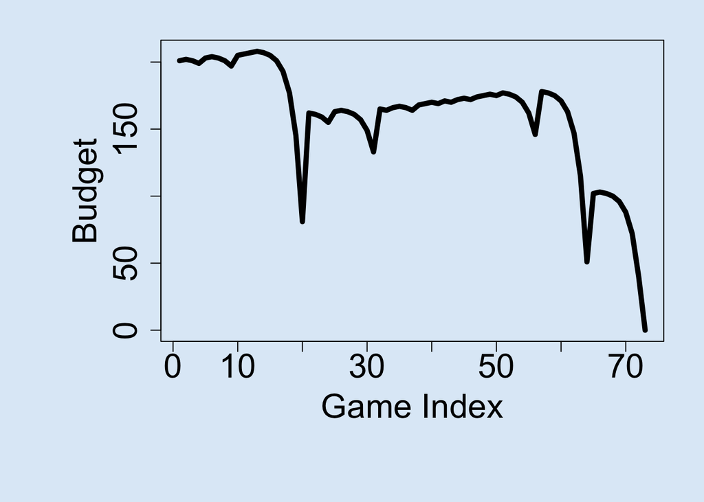

```r
# Code to simulate a sinle spin of the Roulette wheel
single_spin <- function(){
  possible_outcomes <- c(rep("red",18), rep("black",18), rep("green",2))
  sample(possible_outcomes, 1)
}
# Update wager
martingale_wager <- function(
  previous_wager
  , previous_outcome
  , max_wager
  , current_budget
){
  if(previous_outcome == "red") return(1)
  min(2*previous_wager, max_wager, current_budget)
}
# Create ledger using budget and wager
one_play <- function(previous_ledger_entry, max_wager){
  # Create a copy of the input object that will become the output object
  out <- previous_ledger_entry
  out[1, "game_index"] <- previous_ledger_entry[1, "game_index"] + 1
  out[1, "starting_budget"] <- previous_ledger_entry[1, "ending_budget"]
  out[1, "wager"] <- martingale_wager(
    previous_wager = previous_ledger_entry[1, "wager"]
    , previous_outcome = previous_ledger_entry[1, "outcome"]
    , max_wager = max_wager
    , current_budget = out[1, "starting_budget"]
  )
  out[1, "outcome"] <- single_spin()
  out[1, "ending_budget"] <- out[1, "starting_budget"] +
    ifelse(out[1, "outcome"] == "red", +1, -1)*out[1, "wager"]
  return(out)
}
one_series <- function(
  max_games, starting_budget, winning_threshold, max_wager
){
  # Initialize ledger
  ledger <- data.frame(
      game_index = 0:max_games
    , starting_budget = NA_integer_
    , wager = NA_integer_
    , outcome = NA_character_
    , ending_budget = NA_integer_
  )
  ledger[1, "wager"] <- 1
  ledger[1, "outcome"] <- "red"
  ledger[1, "ending_budget"] <- starting_budget
  for(i in 2:nrow(ledger)){
    #browser()
    ledger[i,] <- one_play(ledger[i-1,], max_wager)
    if(stopping_rule(ledger[i,], winning_threshold)) break
  }
  # Return non-empty portion of ledger
  ledger[2:i, ]
}
# Stopping conditions
stopping_rule <- function(
  ledger_entry
  , winning_threshold
){
  ending_budget <- ledger_entry[1, "ending_budget"]
  if(ending_budget <= 0) return(TRUE)
  if(ending_budget >= winning_threshold) return(TRUE)
  FALSE
}
# Profit function subtracting ending budget from beginning budget
profit <- function(ledger){
  n <- nrow(ledger)
  profit <- ledger[n, "ending_budget"] - ledger[1, "starting_budget"]
  return(profit)
}
# Chart showing how gamblers earnings evolve over a series of plays
require(magrittr)
svg(filename = "loser.svg", width=16, height =9)
par(cex.axis=2, cex.lab = 2, mar = c(8,8,2,2), bg = rgb(222, 235, 247, max = 255))
set.seed(1)
ledger <- one_series(200,200,300,500)
plot(ledger[,c(1,5)], type = "l", lwd = 5, xlab = "Game Index", ylab = "Budget")
```

```r
dev.off()
```

```r
svg(filename = "winner.svg", width=16, height =9)
par(cex.axis=2, cex.lab = 2, mar = c(8,8,2,2), bg = rgb(222, 235, 247, max = 255))
set.seed(2)
l2 <- one_series(200,200,300,500)
plot(l2[,c(1,5)], type = "l", lwd = 5, xlab = "Game Index", ylab = "Budget")
dev.off()
```

In the graph above you can see how a gambler’s budget slowly, but surely declines over a number (~70-75) plays.

# 4 Conclusions

There is one main conclusions I came to after running multiple simulations. As a gambler, in order to have the best chance at being profitable, you want wager larger amounts and play as few times as possible.

However, there are certain limitations of the Martingale betting strategy. One that comes to mind is the maximum wager on a single play. If a gambler goes on an extended losing streak, which is bound to happen, then the gambler could reach the maximum wager. If the gambler loses the roll of the maximum wager, then the gambler will not be able to double the wager on the next roll. This will cause the gambler to not profit the $1 like on the other wins. Also, this extended losing streak could be costly to a gambler whose budget is not large, as doubling your bets for each loss can be expensive.